# STA 141: Analysis of Covid Case Growth Rates Across Different Countries

Group 12

3/2/2021

## Introduction

The results of this data analysis could better inform us on the effectiveness of mask and testing policy in stemming the spread of COVID-19. In turn, this information could have significant public policy implications as countries decide whether or not to implement mask mandates and introduce more widespread testing to combat the COVID-19 pandemic. The results of this analysis can be used to build political and public support either for or against these measures based on its results. Additionally, if such policies are shown to be effective in stemming the spread of COVID-19, this analysis would allow researchers to better forecast the impact of COVID-19 on countries based on whether or not they had implemented the mentioned policies by April 1st, 2020.

We will be examining two datasets in this report. One was produced by the World Health Organization (WHO) regarding the COVID-19 pandemic. This dataset features the following variables of interest: number of new COVID cases, deaths attributable to COVID-19, and a cumulative measure of both data points since January 3rd, 2020 until the present. Data has been compiled from all countries that are members of the WHO. The second dataset was published in the journal Nature and includes data from the European Center for Disease Prevention and Control, Oxford, and other sources. This particular dataset examines the response of governments to COVID-19. Some of the key variables from this dataset that will be relied on for this report include: obligation to wear masks (binary value tracking whether or not mask mandate is in place), testing policy (binary value tracking whether or not a public testing policy is in place), number of new cases reported each day for each respective country, etc.

At the onset, we hypothesize that because masks prevent air from flowing between persons, they will be effective in reducing the transmission of COVID-19 amongst a population. Therefore, we expect to see that countries that implemented the mask mandate on or before April 1st, 2020 had a lower new case proportion growth versus countries that did not implement such policies until after the mentioned date. Furthermore, having a public testing policy would allow COVID-19 cases to be caught early on so that people can go into isolation and minimize their likelihood of spreading the virus to other people. Instituting a lockdown would be expected to have a similar impact. So it can also be hypothesized that countries with public testing policies and/or a lockdown in place may have lower new case proportion growth.

## Background

As previously mentioned, two datasets were used in the creation of this analysis. The first such dataset was obtained from the WHO and featured variables pertaining to new cases of COVID-19 infections as well as deaths attributable to the virus. As aforementioned, this data had been harvested since January 3rd 2020 up to the present. The WHO went about obtaining the information needed for this dataset by collecting data via official communications, which were conducted per International Health Regulations, and supplemented this with data reported by countries’ governmental health agencies (this includes any information disclosed by these agencies on their websites and social media channels). During this process, the number of new cases and deaths catalogued were only recorded if these cases were laboratory-confirmed and fell within the WHO’s definitions for confirmed cases. Specifically, in order to be classified as a new case of COVID-19, a person would have to have a positive Nucleic Acid Amplification Test result and/or be identified as being positive for the SARS-CoV-2 Antigen. Additional data apart from that reported by member countries was obtained from the European Center for Disease Prevention and Control. Possible sources of bias in this dataset may include: bias on the part of health ministries in WHO member countries when reporting their data, lack of accurate reporting from WHO member countries with underdeveloped health systems and lack of significant healthcare infrastructure, bias in the AI web-scraping algorithm used to harvest data from public press releases and social media posts made by governmental health agencies, etc.

The second dataset was obtained from the University of Oxford’s COVID-19 Government response tracker and features several variables documenting the governmental response of countries to the COVID-19 pandemic. In total, 13 public health measures and 7 measures of economic policy were catalogued in this dataset. Each of these measures were assessed with a binary datapoint (1 or 0) depending on whether or not the policy indicated had been implemented by the country in question. In a few cases, a measure of “0.5” was used to denote partial implementation of a particular policy. Those of particular interest for this analysis included: obligation to wear masks in public settings, whether or not a public testing policy was in place, and whether or not a domestic lockdown had been initiated. Data for each of the public health measures catalogued by the dataset were obtained from the Assessment Capacities Project (ACAPs), the International Monetary Fund (IMF), and from information made publicly available by countries’ governmental health agencies. Possible sources of bias in this dataset may include: bias on the part of governmental health agencies when publicly disclosing information about their policy responses to COVID-19, lack of coordinated policy measures implemented by countries with weakly structured governments, etc.

Citation: Hale, Thomas, Noam Angrist, Emily Cameron-Blake, Laura Hallas, Beatriz Kira, Saptarshi Majumdar, Anna Petherick, Toby Phillips, Helen Tatlow, Samuel Webster (2020). Oxford COVID-19 Government Response Tracker, Blavatnik School of Government.

Existing research published in the American Journal of Tropical Medicine and Hygiene as well as by the National Academy of Sciences in the United States has shown that COVID-19 transmission rates are forecasted to be 7.5 times higher in countries without a mask mandate as opposed to countries with one in place. And as expected, countries with a mask mandate have a lower COVID-19 related mortality rate than those that have not implemented such policies. Additionally, it was observed that the duration of time spent in lockdown was inversely correlated with COVID-19 related mortality rate, which is also in line with expectations. On the other hand, increased public testing for COVID-19 was shown to not have a statistically significant relationship with COVID-19 related mortality rate. Citation: Leffler, Christoper T, et al. “Association of Country-Wide Coronavirus Mortality with Demographics, Testing, Lockdowns, and Public Wearing of Masks.” The American Journal of Tropical Medicine and Hygiene, vol. 103, no. 6, 13 Aug. 2020, pp. 2400–2411., doi:https://doi.org/10.4269/ajtmh.20-1015.

## Decriptive Analysis

```r
covid <- read_csv("https://covid19.who.int/WHO-COVID-19-global-data.csv")

policy <- read_excel("Data/Gov_Responses2Covid19_last.xlsx")
```

```r
by_country <- policy %>%
  group_by(country)

policy2 <- by_country %>%
  subset(d=='31aug2020' | d=='01apr2020')

for (x in 1:nrow(policy2)) {
  if (policy2$d[x]=='31aug2020') {
    policy2$d[x]<-'2020-08-31'
  }
  else {
    policy2$d[x]<-'2020-4-01'
  }
}

covid2 <- covid %>%
  subset(Date_reported=='2020-08-31' | Date_reported=='2020-04-01')

policy2$date<-as.Date(policy2$d, "%Y-%m-%d")

policy2<-policy2 %>%
  subset(select=-c(d))

df<-merge(x=policy2, y=covid2, by.x=c("geoid", "date"), by.y=c("Country_code", "Date_reported"))
df<-df %>%
  mutate(case_proportion=(Cumulative_cases/as.numeric(population_2019)))
```

Adding case mortality column

```r
df$Case_mort = df$Cumulative_deaths/df$Cumulative_cases
```

```r
glimpse(df)
```

```
## Rows: 442
## Columns: 51
## $ geoid                  <chr> "AD", "AD", "AE", "AE", "AF", "AF", "AG", "A...
## $ date                   <date> 2020-04-01, 2020-08-31, 2020-04-01, 2020-08...
## $ country                <chr> "Andorra", "Andorra", "United Arab Emirates"...
## $ iso                    <chr> "AND", "AND", "ARE", "ARE", "AFG", "AFG", "A...
## $ cases                  <dbl> 6, 0, 53, 362, 25, 19, 0, 0, 0, 0, 20, 101, ...
## $ deaths                 <dbl> 4, 0, 1, 3, 0, 0, 0, 0, 0, 0, 3, 5, 0, 5, 0,...
## $ school                 <dbl> 1, NA, NA, 1, 1, 1, 1, NA, 1, NA, 1, NA, 1, ...
## $ school_local           <dbl> 0, NA, NA, 1, 0, 1, 0, NA, 0, NA, 0, NA, 0, ...
## $ domestic               <dbl> NA, NA, 1, 0, 1, 0, 1, 0, 0, 0, 1, 0, 1, 0, ...
## $ domestic_local         <dbl> NA, NA, 0, 0, 1, 0, 0, 0, 0, 0, 0, 0, 0, 0, ...
## $ travel                 <dbl> NA, NA, 1, 0, 1, 0, 1, 0, 0, 0, 1, 0, 1, 1, ...
## $ travel_partial         <dbl> NA, NA, 1, 0, 0, 0, 1, 0, 0, 0, 0, 0, 1, 1, ...
## $ travel_dom             <dbl> NA, NA, 0, 0, 0, 0, 0, 0, 0, 0, 0, 0, 0, 0, ...
```

[output cut: 38 more lines]

#summary statistics

```r
# earliet date
min(covid$Date_reported)
```

```
## [1] "2020-01-03"
```

```r
# Latest date
max(covid$Date_reported)
```

```
## [1] "2021-03-05"
```

```r
# Halfway point
median(covid$Date_reported)
```

```
## [1] "2020-08-03"
```

```r
summary(df$cases)
```

```
##    Min. 1st Qu.  Median    Mean 3rd Qu.    Max.    NA's
##     0.0     0.0    15.0   757.4   123.2 78512.0      30
```

```r
summary(df$deaths)
```

```
##    Min. 1st Qu.  Median    Mean 3rd Qu.    Max.    NA's
##    0.00    0.00    0.00   19.52    2.00  971.00      30
```

```r
summary(df$Case_mort)
```

```
##    Min. 1st Qu.  Median    Mean 3rd Qu.    Max.    NA's
## 0.00000 0.00328 0.01668 0.02745 0.03168 0.33333      40
```

```r
df[which.max(df$Case_mort),]
```

```
##     geoid       date country iso cases deaths school school_local domestic
## 147    GM 2020-04-01  Gambia GMB     0      0      1            0        0
##     domestic_local travel travel_partial travel_dom travel_dom_partial curf
## 147              0      1              0          0                  0    0
##     curf_partial mass mass_partial elect elect_partial sport sport_partial rest
## 147            0    1            0     1             1     1             0    1
##     rest_local testing testing_narrow masks masks_partial surveillance
## 147          0       0              0     0             0            0
##     surveillance_partial state state_partial cash wage credit taxc taxd export
## 147                    0     1             0    0    0      0    0    0      0
##     rate Rigidity_Public_Health Economic_Measures population_2019 continent
## 147    1                     .5          .1428571         2.3e+06    Africa
##     Country WHO_region New_cases Cumulative_cases New_deaths Cumulative_deaths
## 147  Gambia       AFRO         0                3          0                 1
##     case_proportion Case_mort
## 147    1.304348e-06 0.3333333
```

```r
### CREATE VARIABLE FOR CASE GROWTH RATE BETWEEN APRIL 01 AND AUGUST 31 ###
for (country in 1:nrow(df)) {

  df$growth2[country]<-log(((df$Cumulative_cases[country+1])-(df$Cumulative_cases[country]))/(df$Cumulative_cases[country]))
}

na.index<-is.na(df$growth2)
inf.index<-is.infinite(df$growth2)
nan.index<-is.nan(df$growth2)
df.growthrates<-df[!na.index & !inf.index & !nan.index,]
```

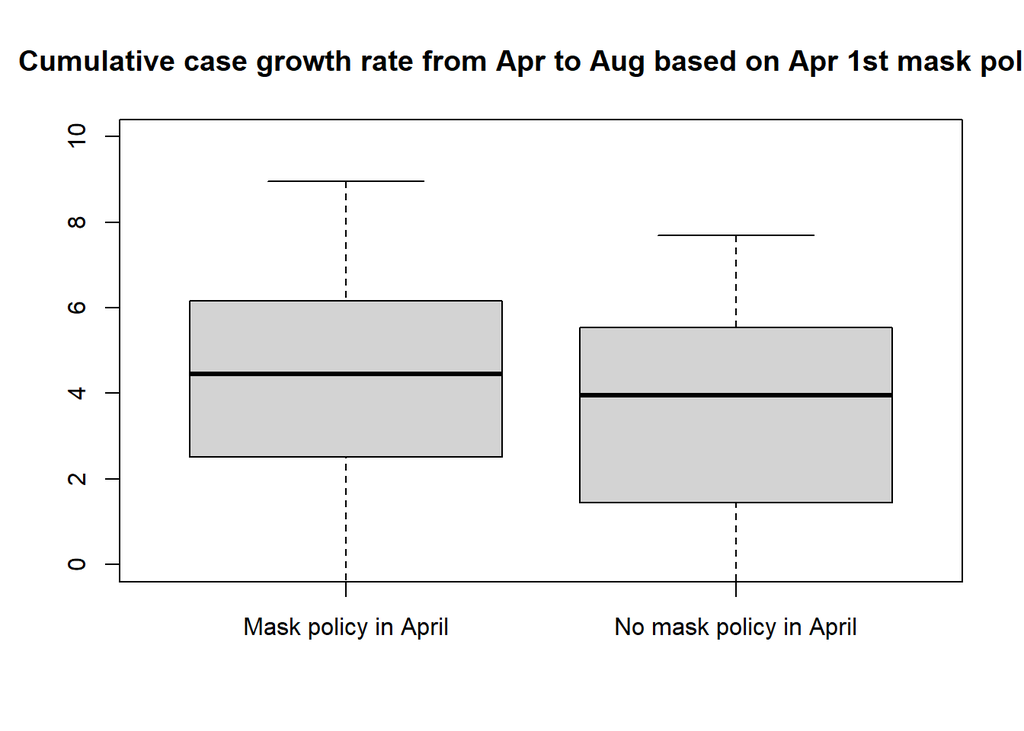

```r
### GENERATE BOXPLOT FOR COUNTRIES WHICH HAD MASK POLICY IN APRIL VERSUS NO MASK POLICY IN APRIL ###

df.maskapril<-subset(df.growthrates, masks==1 & date=='2020-04-01')

df.augresult<-subset(df.growthrates, df$country %in% df.maskapril$country & date=='2020-04-01')

#mask.result<-summary(df.augresult$case_proportion)


df.nomaskapril<-subset(df.growthrates, masks==0 & date=='2020-04-01')

df.augresult.nm<-subset(df.growthrates, df$country %in% df.nomaskapril$country & date=='2020-04-01')

#nomask.result<-summary(df.augresult.nm$case_proportion)

boxplot(df.augresult$growth2, df.augresult.nm$growth2,
        names=c('Mask policy in April', 'No mask policy in April'),
        ylim=c(0, 10),
        main='Cumulative case growth rate from Apr to Aug based on Apr 1st mask policy')
```

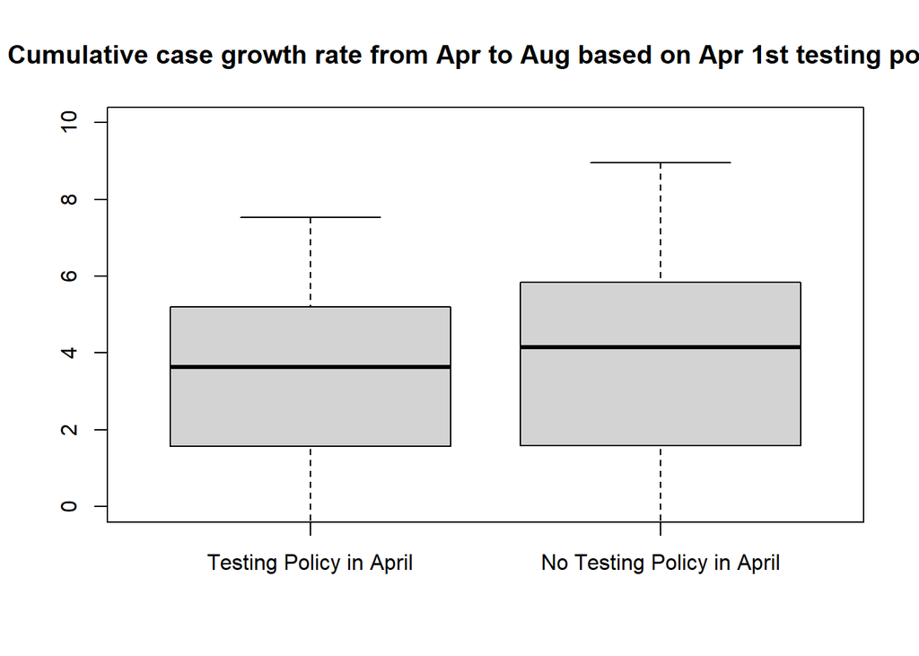

```r
### GENERATE BOXPLOT FOR COUNTRIES WHICH HAD TESTING POLICY IN APRIL VERSUS ###
### NO TESTING POLICY IN APRIL ###

df.test.april<-subset(df.growthrates, testing==1 & date=='2020-04-01')

df.augresult.test<-subset(df.growthrates, df$country %in% df.test.april$country & date=='2020-04-01')

#test.result<-summary(df.augresult.test$case_proportion)


df.notest.april<-subset(df.growthrates, testing==0 & date=='2020-04-01')

df.augresult.notest<-subset(df.growthrates, df$country %in% df.notest.april$country & date=='2020-04-01')

#nomass.result<-summary(df.augresult.notest$case_proportion)

boxplot(df.augresult.test$growth2, df.augresult.notest$growth2,
        names=c('Testing Policy in April', 'No Testing Policy in April'),
        ylim=c(0, 10),
        main='Cumulative case growth rate from Apr to Aug based on Apr 1st testing policy')
```

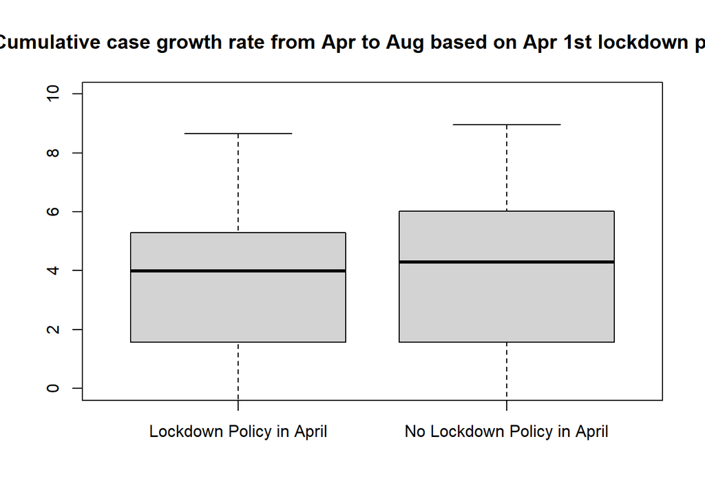

```r
### GENERATE BOXPLOT FOR COUNTRIES WHICH HAD LOCKDOWN POLICY IN APRIL VERSUS ###
### NO LOCKDOWN POLICY IN APRIL ###

df.ld.april<-subset(df.growthrates, domestic==1 & date=='2020-04-01')

df.augresult.ld<-subset(df.growthrates, df$country %in% df.ld.april$country & date=='2020-04-01')

#ld.result<-summary(df.augresult.ld$case_proportion)


df.nold.april<-subset(df.growthrates, domestic==0 & date=='2020-04-01')

df.augresult.nold<-subset(df.growthrates, df$country %in% df.nold.april$country & date=='2020-04-01')

#nold.result<-summary(df.augresult.nold$case_proportion)

boxplot(df.augresult.ld$growth2, df.augresult.nold$growth2,
        names=c('Lockdown Policy in April', 'No Lockdown Policy in April'),
        ylim=c(0,10),
        main='Cumulative case growth rate from Apr to Aug based on Apr 1st lockdown policy')
```

[figure not shown]

```r
### GENERATE BOXPLOT FOR COUNTRIES WHICH HAD RESTURANT POLICY IN APRIL VERSUS ###
### NO LOCKDOWN POLICY IN APRIL ###

df.ld.april<-subset(df.growthrates, rest==1 & date=='2020-04-01')

df.augresult.ld<-subset(df.growthrates, df$country %in% df.ld.april$country & date=='2020-04-01')

ld.result<-summary(df.augresult.ld$case_proportion)


df.nold.april<-subset(df.growthrates, rest==0 & date=='2020-04-01')

df.augresult.nold<-subset(df.growthrates, df$country %in% df.nold.april$country & date=='2020-04-01')

nold.result<-summary(df.augresult.nold$case_proportion)

boxplot(df.augresult.ld$growth2, df.augresult.nold$growth2,
        names=c('Restaurant Closures in April', 'No Rest. Closures in April'),
        ylim=c(0,10),
        main='Cumulative case growth rate from Apr to Aug based on Apr 1st lockdown policy')
```

## Inferential Analysis

Our primary question of interest is whether certain policies enacted at the national and sub-national level may be associated with different outcomes in terms of the cumulative case proportion and growth of cumulative cases a country experiences over a five month period. The policies we have examined include mask wearing obligations, testing implementation, lockdown enforcement, and restaurant closures. These policies were measured according to their implementation on April 1st of 2020. If the policy had been implemented at the national or local level by that date, then the variable takes a variable of one. If the policy had not been implemented, it takes a value of zero.

It is important to emphasize that the goal of this model is not to assess causality, but to determine what factors are associated with certain outcomes.

A secondary question of interest then entails which of these different policies, if any, are associated with country wide case proportions measured five months later on August 31, as well as the average growth rate of cases during that same five month interval.

For the purposes of this study, case proportion is defined as $X_i/N_i$, where $X_i$ represents the cumulative cases recorded for the i-th country on August 31 of 2020, and $N_i$ corresponds to that country’s population in 2019. Cumulative case growth rate is defined as $((X_{i,{t+1}})-(X_{i,t}))/(X_{i,t})$ where $X_{i,{t+1}}$ corresponds to the number of cumulative cases recorded within the i-th country on August 31st, and $X_{i,t}$ corresponds to the number of cumulative cases recorded in the i-th country on April 1st.

We first employ a linear regression model of the form:

$$Y_{i,t+1}=\beta_0+\beta_1masks_{i,t}+\beta_2testing_{i,t}+\beta_3lockdown_{i,t}+\beta_4restaurants \space closed_{i,t}$$

Where each variable is a dummy which takes a value of 1 if the i-th country implemented the respective policy in time period $t$. The outcome is cumulative cases in the i-th country as recorded in time period $t+1$.

The second linear regression model takes a similar form:

$$Y_{i,t+1}=\beta_0+\beta_1masks_{i,t}+\beta_2testing_{i,t}+\beta_3lockdown_{i,t}+\beta_4restaurants \space closed_{i,t}$$

except here the outcome is defined as the log of growth rate in cumulative cases between April 1st and August 31st.

Both models, being linear regression models, rely on several key assumptions.

```
  1) the expected value of the response variable is influenced additively (if no interaction terms are              present) and linearly by the factors

  2) Each sample is independent and selected from an underlying population which is normally distributed

  3) Homogeneity of variance between groups (Homoskedasticity)

  4) The error terms are normally distributed with constant mean and variance
```

```r
## Created a dataframe with just the country, growth rate in August, whether mask testing, lockdown in April

# Can be used for anova model
#masking_policy_april = subset(df, date =='2020-04-01')
#august_results = subset(df, date == "2020-08-31")
#df1 = data.frame( country =masking_policy_april$country, case_growth = august_results$case.growth, masks =masking_policy_april$masks,
                 #lockdown =masking_policy_april$domestic,
                 #testing =masking_policy_april$testing )
```

```r
### Adam model ###



model_case.proportion<-glm(data=df, formula=case_proportion[which(date=='2020-08-31')]~
            masks[which(date=='2020-04-01')]+testing[which(date=='2020-04-01')]+
            domestic[which(date=='2020-04-01')]+rest[which(date=='2020-04-01')])


model_growth.rate<-lm(data=df.growthrates, formula=growth2[which(date=='2020-04-01')]~
            masks[which(date=='2020-04-01')]+testing[which(date=='2020-04-01')]+
            domestic[which(date=='2020-04-01')]+rest[which(date=='2020-04-01')])


summary(model_case.proportion)
```

```
##
## Call:
## glm(formula = case_proportion[which(date == "2020-08-31")] ~
##     masks[which(date == "2020-04-01")] + testing[which(date ==
##         "2020-04-01")] + domestic[which(date == "2020-04-01")] +
##         rest[which(date == "2020-04-01")], data = df)
##
## Deviance Residuals:
##       Min         1Q     Median         3Q        Max
## -0.005240  -0.003342  -0.001406   0.001100   0.037077
##
## Coefficients:
##                                         Estimate Std. Error t value Pr(>|t|)
## (Intercept)                            0.0016982  0.0010484   1.620   0.1072
## masks[which(date == "2020-04-01")]    -0.0004513  0.0013401  -0.337   0.7367
## testing[which(date == "2020-04-01")]  -0.0020121  0.0011410  -1.763   0.0797 .
## domestic[which(date == "2020-04-01")]  0.0011379  0.0009880   1.152   0.2511
## rest[which(date == "2020-04-01")]      0.0024356  0.0011392   2.138   0.0340 *
## ---
## Signif. codes:  0 '***' 0.001 '**' 0.01 '*' 0.05 '.' 0.1 ' ' 1
##
## (Dispersion parameter for gaussian family taken to be 3.4937e-05)
##
##     Null deviance: 0.0060260  on 166  degrees of freedom
## Residual deviance: 0.0056598  on 162  degrees of freedom
##   (54 observations deleted due to missingness)
## AIC: -1232.9
##
## Number of Fisher Scoring iterations: 2
```

```r
summary(model_growth.rate)
```

```
##
## Call:
## lm(formula = growth2[which(date == "2020-04-01")] ~ masks[which(date ==
##     "2020-04-01")] + testing[which(date == "2020-04-01")] + domestic[which(date ==
##     "2020-04-01")] + rest[which(date == "2020-04-01")], data = df.growthrates)
##
## Residuals:
##    Min     1Q Median     3Q    Max
## -6.702 -1.553  0.299  1.717  5.628
##
## Coefficients:
##                                       Estimate Std. Error t value Pr(>|t|)
## (Intercept)                             4.7474     0.4393  10.807  < 2e-16 ***
## masks[which(date == "2020-04-01")]     -0.7886     0.5250  -1.502  0.13513
## testing[which(date == "2020-04-01")]   -1.2511     0.4470  -2.799  0.00578 **
## domestic[which(date == "2020-04-01")]  -0.4370     0.3950  -1.106  0.27034
## rest[which(date == "2020-04-01")]      -0.1969     0.4613  -0.427  0.67015
## ---
## Signif. codes:  0 '***' 0.001 '**' 0.01 '*' 0.05 '.' 0.1 ' ' 1
##
## Residual standard error: 2.309 on 155 degrees of freedom
##   (37 observations deleted due to missingness)
## Multiple R-squared:  0.0813, Adjusted R-squared:  0.05759
## F-statistic: 3.429 on 4 and 155 DF,  p-value: 0.01022
```

We find that the model which measures case proportion in August as an outcome finds restaurant closures to be significant at the $\alpha=0.5$ level. This first model also finds testing to have a statistically significant association with case proportions five months later, at the $\alpha=0.10$ level.

For the second model, we find that testing has a statistically significant association with the log of cumulative case growth rate between August 31 and April 1st, at the $\alpha=0.01$ significance level.

In the final project, we can use Tukey’s Honestly Significantly Difference test to construct pairwise confidence intervals for the different groups.

## Sensitivity Analysis

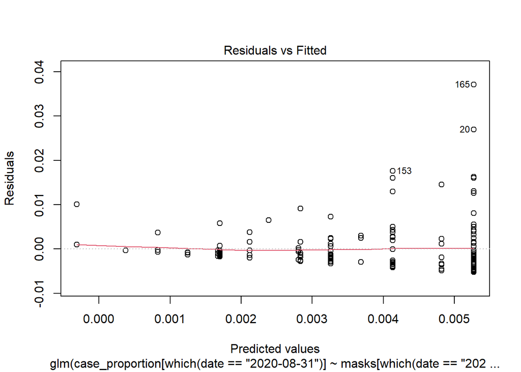

```r
plot(model_case.proportion,which =1)
```

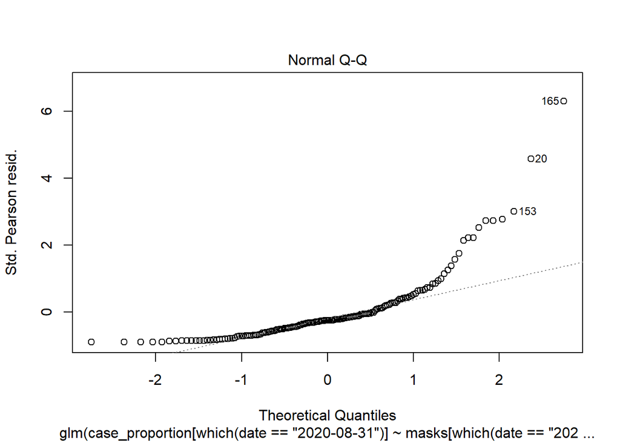

```r
plot(model_case.proportion,which =2)
```

The normal Q-Q plot shows that the errors have heavy tail on the right. Again observations 20,153,165 are contributing to the problem. The errors are not normally distributed.

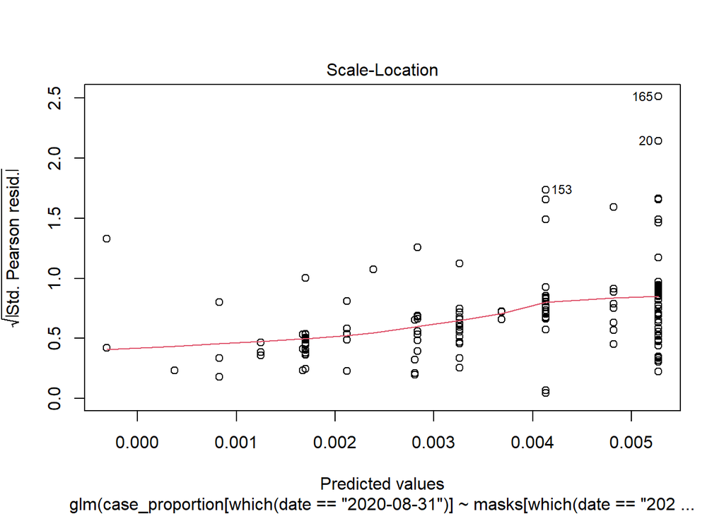

```r
plot(model_case.proportion,which =3)
```

The scale location plot is also used to check the equal variance assumption. Again it is visible that the spread of variance increases as the predicted value increases. Also as expected observations 20, 153 and 165 are still outliers.

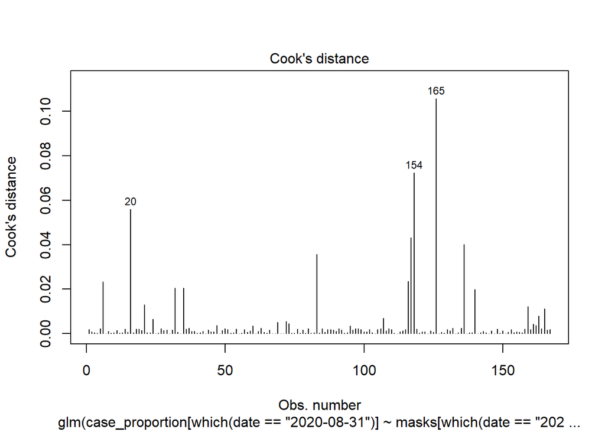

```r
plot(model_case.proportion,which =4)
```

Using an alternative model that looked at case growth rate in August as the response variable the we get the following sensitivity results for the model.

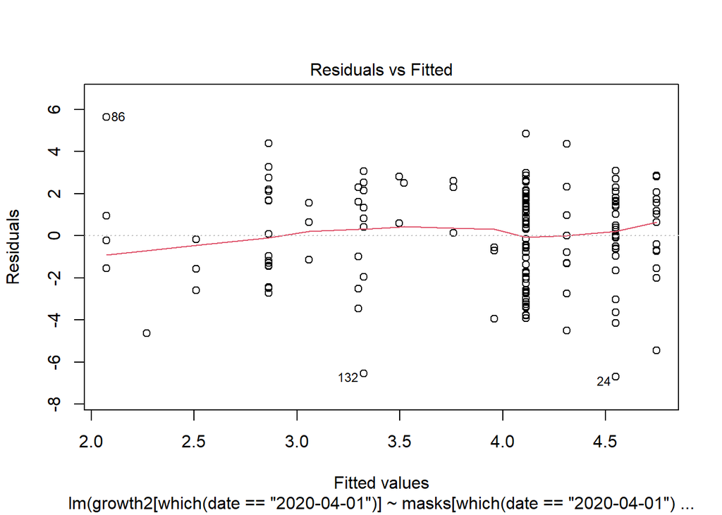

```r
# New case growth rate model
plot(model_growth.rate,which =1)
```

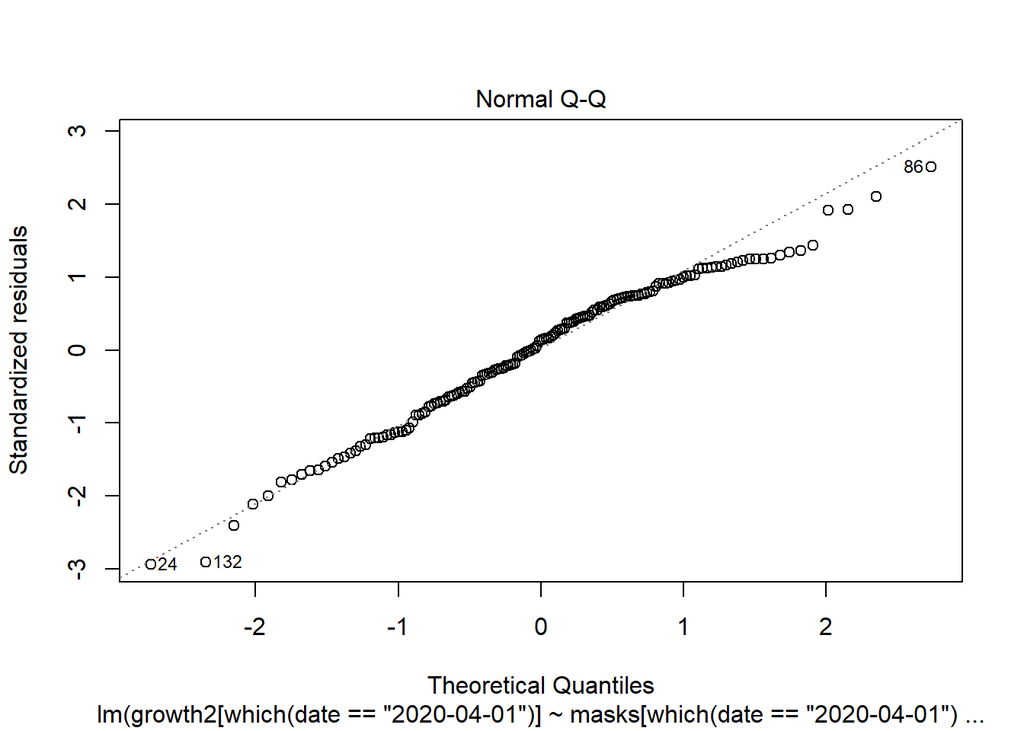

```r
plot(model_growth.rate,which =2)
```

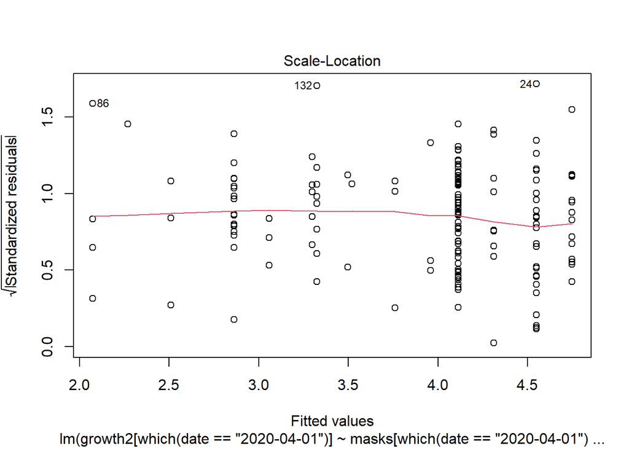

```r
plot(model_growth.rate,which =3)
```

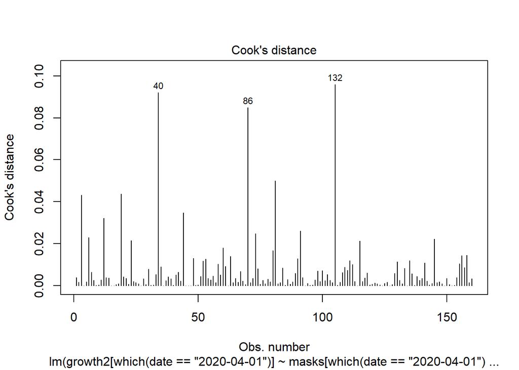

```r
plot(model_growth.rate,which =4)
```

```r
  tmp =df.growthrates$growth2[which(df.growthrates$date=='2020-04-01')]
mean(tmp)
```

```
## [1] 3.637807
```

```r
sd(tmp)
```

```
## [1] 2.381542
```

```r
tmp[86]
```

```
## [1] 7.701867
```

## Discussion & Conclusion

For future research and policy making, one can create a model where vaccination and immunity data is also taken into consideration and applied into the model. This model would produce more current up to date results as vaccinations have just begun to ramp up in the “Americas” regions, which means that one can hypothesize that new case proportions would go down.